# AllLife Bank Credit Card Customer Segmentation

## Context

AllLife Bank wants to focus on its credit card customer base in the next financial year. They have been advised by their marketing research team, that the penetration in the market can be improved. Based on this input, the Marketing team proposes to run personalized campaigns to target new customers as well as upsell to existing customers. Another insight from the market research was that the customers perceive the support services of the back poorly. Based on this, the Operations team wants to upgrade the service delivery model, to ensure that customer queries are resolved faster. Head of Marketing and Head of Delivery both decide to reach out to the Data Science team for help.

## Objective

To identify different segments in the existing customer, based on their spending patterns as well as past interaction with the bank, using clustering algorithms, and provide recommendations to the bank on how to better market to and service these customers.

### Data Description

```
-Sl_No. Primary key of the recor
-Customer Key: Customer identification number
-Average Credit Limit: Average credit limit of each customer for all credit cards
-Total credit cards: Total number of credit cards possessed by the customer
-Total visits bank: Total number of visits that customer made (yearly) personally to the bank
-Total visits online: Total number of visits or online logins made by the customer (yearly)
-Total calls made: Total number of calls made by the customer to the bank or its customer service department (yearly)
```

### Importing necessary libraries

```python
# Libraries to help with reading and manipulating data
import numpy as np
import pandas as pd

# Libraries to help with data visualization
import matplotlib.pyplot as plt
import seaborn as sns

plt.style.use("ggplot")
sns.set_style("darkgrid")
sns.set()

# Removes the limit for the number of displayed columns
pd.set_option("display.max_columns", None)
# Sets the limit for the number of displayed rows
pd.set_option("display.max_rows", 200)

# to scale the data using z-score
from sklearn.preprocessing import StandardScaler

# to compute distances
from scipy.spatial.distance import pdist
from scipy.spatial.distance import cdist

# to perform hierarchical clustering, compute cophenetic correlation, and create dendrograms
from sklearn.cluster import AgglomerativeClustering
from scipy.cluster.hierarchy import dendrogram, linkage, cophenet

# to perform k-means clustering and compute silhouette scores
from sklearn.cluster import KMeans
from sklearn.metrics import silhouette_score

try:
    from sklearn.utils import safe_indexing
except ImportError:
    from sklearn.utils import _safe_indexing

# to visualize the elbow curve and silhouette scores
from yellowbrick.cluster import KElbowVisualizer, SilhouetteVisualizer

# to perform PCA
from sklearn.decomposition import PCA

# this will help in making the Python code more structured automatically (good coding practice)
%load_ext nb_black

# supress numerical display to 2 points of precision in scientific notation
pd.set_option("display.float_format", lambda x: "%.2f" % x)

import warnings

warnings.filterwarnings("ignore")
from statsmodels.tools.sm_exceptions import ConvergenceWarning

warnings.simplefilter("ignore", ConvergenceWarning)

import tensorflow as tf
print(tf.__version__)

# Removes the limit for the number of displayed columns
pd.set_option("display.max_columns", None)
# Sets the limit for the number of displayed rows
pd.set_option("display.max_rows", 200)
```

```
2.9.1
```

# Data Pre Processing

```python
# loading the dataset
df = pd.read_csv("CreditCardCustomerData.csv")
```

### View the random 10 rows of the dataset.

```python
# viewing a random sample of the dataset
df.sample(n=10, random_state=1)
```

|  | Sl_No | Customer Key | Avg_Credit_Limit | Total_Credit_Cards | Total_visits_bank | Total_visits_online | Total_calls_made |
| --- | --- | --- | --- | --- | --- | --- | --- |
| 547 | 548 | 38125 | 26000 | 4 | 5 | 2 | 4 |
| 353 | 354 | 94437 | 9000 | 5 | 4 | 1 | 3 |
| 499 | 500 | 65825 | 68000 | 6 | 4 | 2 | 2 |
| 173 | 174 | 38410 | 9000 | 2 | 1 | 5 | 8 |
| 241 | 242 | 81878 | 10000 | 4 | 5 | 1 | 3 |
| 341 | 342 | 70779 | 18000 | 4 | 3 | 2 | 0 |
| 647 | 648 | 79953 | 183000 | 9 | 0 | 9 | 2 |
| 218 | 219 | 28208 | 19000 | 3 | 1 | 5 | 7 |
| 120 | 121 | 16577 | 10000 | 4 | 2 | 4 | 6 |
| 134 | 135 | 31256 | 13000 | 4 | 1 | 5 | 7 |

```python
print(
    f"There are {df.shape[0]} rows and {df.shape[1]} columns in the credit card dataset."
)
```

```
There are 660 rows and 7 columns in the credit card dataset.
```

### Check the data types of the columns for the dataset.

```python
# checking datatypes and number of non-null values for each column
df.info()
```

```
<class 'pandas.core.frame.DataFrame'>
RangeIndex: 660 entries, 0 to 659
Data columns (total 7 columns):
 #   Column               Non-Null Count  Dtype
---  ------               --------------  -----
 0   Sl_No                660 non-null    int64
 1   Customer Key         660 non-null    int64
 2   Avg_Credit_Limit     660 non-null    int64
 3   Total_Credit_Cards   660 non-null    int64
 4   Total_visits_bank    660 non-null    int64
 5   Total_visits_online  660 non-null    int64
 6   Total_calls_made     660 non-null    int64
dtypes: int64(7)
memory usage: 36.2 KB
```

**Observations**

- There are no rows that have null values for any of the features
- All of the records are numerical (int64)

### Summary of the dataset.

```python
# Let's look at the statistical summary of the data
df.describe(include="all").T  ### Summary of the dataset.
```

|  | count | mean | std | min | 25% | 50% | 75% | max |
| --- | --- | --- | --- | --- | --- | --- | --- | --- |
| Sl_No | 660.00 | 330.50 | 190.67 | 1.00 | 165.75 | 330.50 | 495.25 | 660.00 |
| Customer Key | 660.00 | 55141.44 | 25627.77 | 11265.00 | 33825.25 | 53874.50 | 77202.50 | 99843.00 |
| Avg_Credit_Limit | 660.00 | 34574.24 | 37625.49 | 3000.00 | 10000.00 | 18000.00 | 48000.00 | 200000.00 |
| Total_Credit_Cards | 660.00 | 4.71 | 2.17 | 1.00 | 3.00 | 5.00 | 6.00 | 10.00 |
| Total_visits_bank | 660.00 | 2.40 | 1.63 | 0.00 | 1.00 | 2.00 | 4.00 | 5.00 |
| Total_visits_online | 660.00 | 2.61 | 2.94 | 0.00 | 1.00 | 2.00 | 4.00 | 15.00 |
| Total_calls_made | 660.00 | 3.58 | 2.87 | 0.00 | 1.00 | 3.00 | 5.00 | 10.00 |

**Observations**

```python
# Get counts of unique values for Sl_No and Customer Key
unique_counts = df[["Sl_No", "Customer Key"]].nunique()

print(unique_counts)
```

```
Sl_No           660
Customer Key    655
dtype: int64
```

**Observations**

- SI_No doesn't have any duplicate values but Customer Key does (5 rows)

```python
# Let's see the records where Customer Key is duplicated
duperows = df[df.duplicated(subset=["Customer Key"], keep=False)]

print(duperows.sort_values(by="Customer Key"))
```

```
     Sl_No  Customer Key  Avg_Credit_Limit  Total_Credit_Cards  \
48      49         37252              6000                   4
432    433         37252             59000                   6
4        5         47437            100000                   6
332    333         47437             17000                   7
411    412         50706             44000                   4
541    542         50706             60000                   7
391    392         96929             13000                   4
398    399         96929             67000                   6
104    105         97935             17000                   2
632    633         97935            187000                   7

     Total_visits_bank  Total_visits_online  Total_calls_made
48                   0                    2                 8
432                  2                    1                 2
4                    0                   12                 3
332                  3                    1                 0
411                  5                    0                 2
541                  5                    2                 2
391                  5                    0                 0
398                  2                    2                 2
104                  1                    2                10
632                  1                    7                 0
```

**Observations**

- Even though the Customer Key is duplicated in these records, for each given Customer Key the other columns are different. Therefore we will assume that the customers are all different in someway (personal account vs joint account or personal vs business) and we will not delete any of these.

```python
# Drop the Customer Key and SI columns
df.drop(["Sl_No", "Customer Key"], axis=1, inplace=True)
```

```python
# Let's look at the values for all the features except for Avg_Credit_Limit because there are too many values

select_cols = [
    "Total_Credit_Cards",
    "Total_visits_bank",
    "Total_visits_online",
    "Total_calls_made",
]

for column in select_cols:
    print(df[column].value_counts(1) * 100)
    print("-" * 50)
```

```
4    22.88
6    17.73
7    15.30
5    11.21
2     9.70
1     8.94
3     8.03
10    2.88
9     1.67
8     1.67
Name: Total_Credit_Cards, dtype: float64
--------------------------------------------------
2   23.94
1   16.97
0   15.15
```

[output cut: 36 more lines]

**Observations**

- Nothing strange appears here
- 15% of the customers don't visit the bank during the year
- 22% of the customers don't login to their accounts during the year
- 15% of the customers don't call the bank during the year.

## EDA

### Univariate Analysis

```python
def histogram_boxplot(feature, figsize=(12, 8), bins=None):
    """Boxplot and histogram combined
    feature: 1-d feature array
    figsize: size of fig (10,6)
    bins: number of bins (default None/auto)
    """
    f2, (ax_box2, ax_hist2) = plt.subplots(
        nrows=2,
        sharex=True,
        gridspec_kw={"height_ratios": (0.25, 0.75)},
        figsize=figsize,
    )
    sns.boxplot(feature, ax=ax_box2, showmeans=True, color="lightblue")
    sns.distplot(
        feature, kde=F, ax=ax_hist2, bins=bins, palette="pastel"
    ) if bins else sns.distplot(feature, kde=False, ax=ax_hist2, color="red")
    ax_hist2.axvline(
        np.mean(feature), color="green", linestyle="--"
    )  # Add mean to the histogram
    ax_hist2.axvline(
        np.median(feature), color="black", linestyle="-"
    )  # Add median to the histogram
```

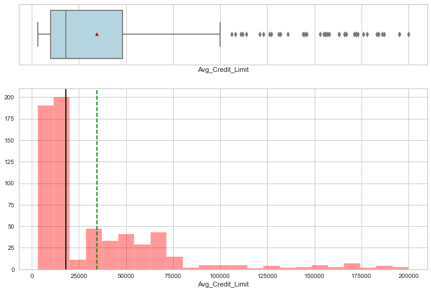

```python
histogram_boxplot(df["Avg_Credit_Limit"])
```

**Observations**

- Avg_Credit_Limit is right skewed with to the right
- There are many outliers where the limit is greater than 100,000 but they are believable and realistic
- Since there are so many records where the credit limit is greater than 100k, we will leave them as is

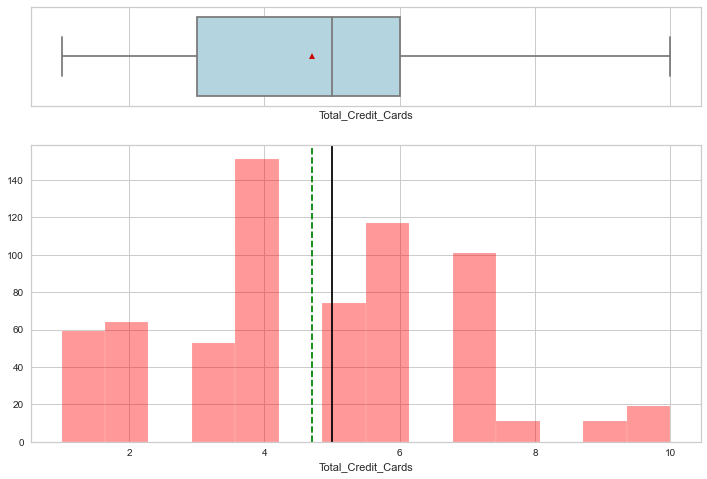

```python
histogram_boxplot(df["Total_Credit_Cards"])
```

**Observations**

- The median and mean are close to each other so the distribution of the amount of credit cards is similar to a normal distribution.
- Having 4 credit cards is the most common bucket followed by 6

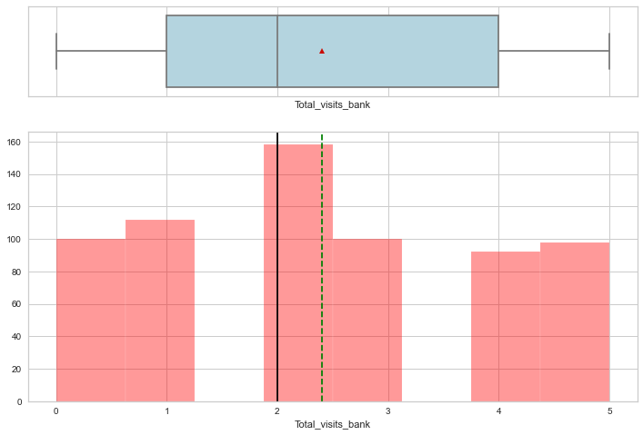

```python
histogram_boxplot(df["Total_visits_bank"])
```

**Observations**

- The median and mean are close to each other so the distribution of the amount of credir cards is similar to a normal distribution.
- The most common bucket for visits is 2/year followed by 1.
- There are no outliers

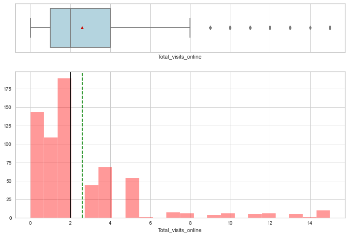

```python
histogram_boxplot(df["Total_visits_online"])
```

**Observations**

- Total_visits_online is right skewed.
- The largest bucket for online visits is 2 followed by 0.
- There are some outliers where customers visit more than 8 times in a year but they are believable and not outrageous and will therefore be not be transformed.

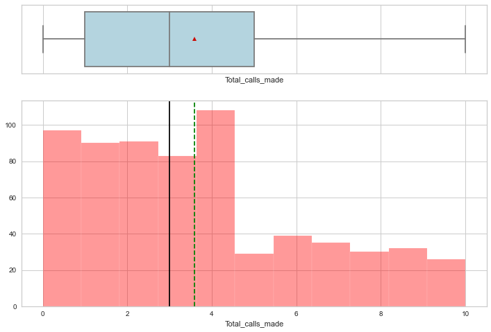

```python
histogram_boxplot(df["Total_calls_made"])
```

**Observations**

- The most popular bucket for people to make calls is 4/year followed by 0.
- There are no outloutliers

### Bivariate Analysis

**Let's check for correlations.**

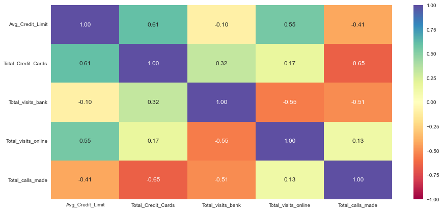

```python
plt.figure(figsize=(15, 7))
sns.heatmap(df.corr(), annot=True, vmin=-1, vmax=1, fmt=".2f", cmap="Spectral")
plt.show()
```

**Observations**

- Total_Credit_Cards is positively correlated with Avg_Credit_Limit (0.61) and Total_visits_bank (0.32); and negatively correlated with Total_calls_made (-0.65).
- Total_visits_bank is negatively correlated with Total_visits_online (-0.55) and Total_calls_made (-0.51) which makes perfect sense because if they are calling in or logging into their accounts it takes away the need to visit the bank.
- Total_visits_online is positively correlated with Avg_Credit_Limit (0.55).

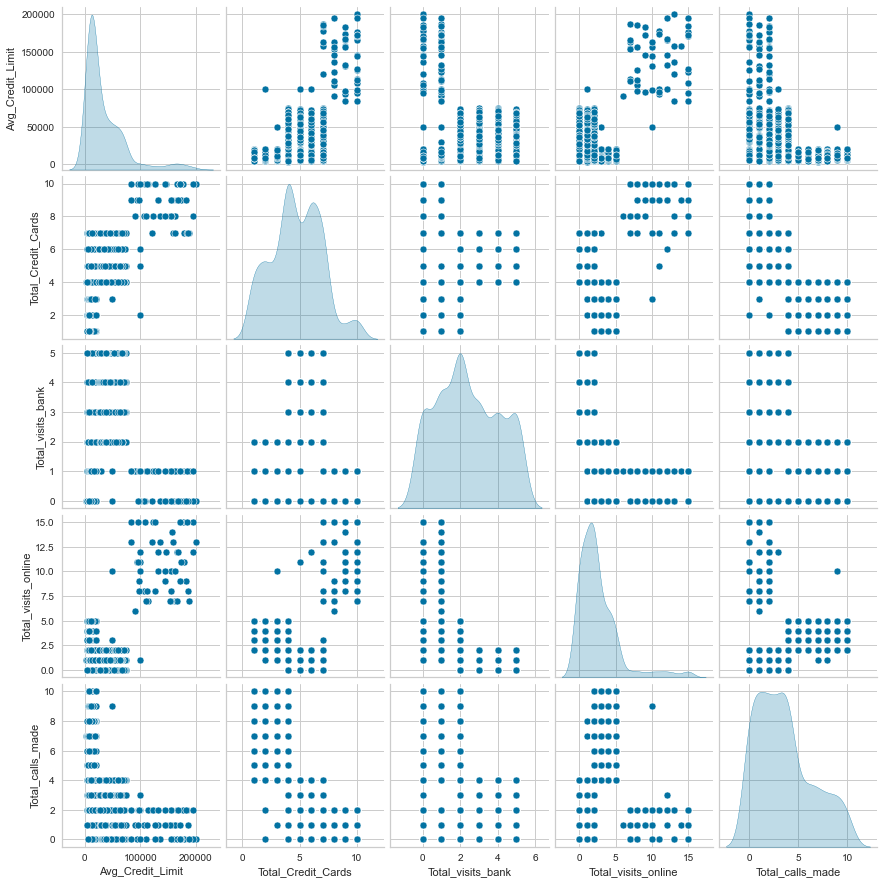

```python
# pairplot: Visualize pairwise relationship in the dataset.
sns.pairplot(df, diag_kind="kde")
```

**Observations**

- Avg_Credit_Limit has 3 distribution peaks.
- Total_Credit_Cards has 4 distribution peaks.
- Total_visits_bank has has 5 distribution peaks.
- Total_visits_online has 2-3 distribution peaks.
- Total_calls_made has 3-4 distribution peaks.

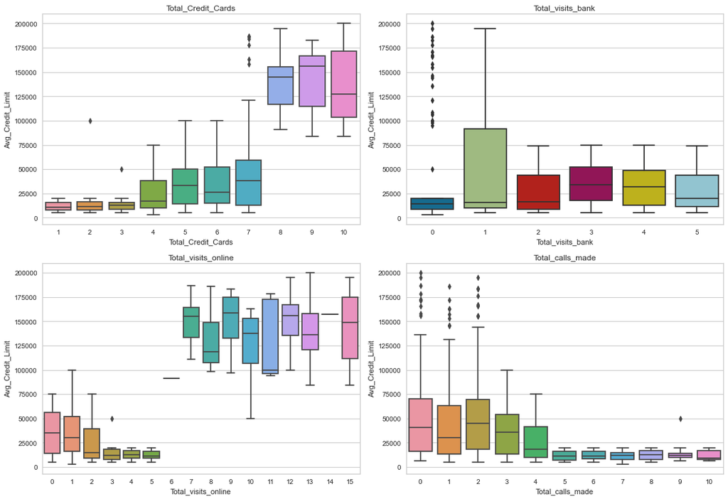

```python
cols = df[
    [
        "Total_Credit_Cards",
        "Total_visits_bank",
        "Total_visits_online",
        "Total_calls_made",
    ]
].columns.tolist()
plt.figure(figsize=(15, 15))

for i, variable in enumerate(cols):
    plt.subplot(3, 2, i + 1)
    sns.boxplot(df[variable], df["Avg_Credit_Limit"])
    plt.tight_layout()
    plt.title(variable)
plt.show()
```

**Observations of Avg_Credit_Limit vs Other Features**

### EDA Summary

- Avg_Credit_Limit is right skewed with to the right and has many outliers where the limit is greater than 100,000 but they are believable and realistic
- Total_Credit_Cards: The median and mean are close to each other so the distribution of the amount of credit cards is similar to a normal distribution.
- Having 4 credit cards is the most common bucket followed by 6
- Total_visits_bank: The most common bucket for bank visits is 2/year followed by 1.
- Total_visits_online: The largest bucket for online visits is 2 followed by 0.
- There are some outliers where customers visit more than 8 times in a year but they are believable and not outrageous
- Total_calls_made: The most popular bucket for people to make calls is 4/year followed by 0.
- Total_Credit_Cards is positively correlated with Avg_Credit_Limit (0.61) and Total_visits_bank (0.32); and negatively correlated with Total_calls_made (-0.65).
- Total_visits_bank is negatively correlated with Total_visits_online (-0.55) and Total_calls_made (-0.51) which makes perfect sense because if they are calling in or logging into their accounts it takes away the need to visit the bank.
- Total_visits_online is positively correlated with Avg_Credit_Limit (0.55).

**Observations of Avg_Credit_Limit vs Other Features**

## Data Preparation

### Checking for Null Values

```python
### Checking for missing values

df.isnull().sum()
```

```
Avg_Credit_Limit       0
Total_Credit_Cards     0
Total_visits_bank      0
Total_visits_online    0
Total_calls_made       0
dtype: int64
```

**Observations**

- As stated earlier there are no null values

### **Let's scale the data**

#### Especially important because of the range of Avg_Credit_Limit in comparison to the others

```python
sc = StandardScaler()
scaled_df = pd.DataFrame(
    sc.fit_transform(df.select_dtypes(include=["int64", "float64"])),
    columns=df.select_dtypes(include=["int64", "float64"]).columns,
    index=df.index,
)

scaled_df.sample(n=10, random_state=1)
```

|  | Avg_Credit_Limit | Total_Credit_Cards | Total_visits_bank | Total_visits_online | Total_calls_made |
| --- | --- | --- | --- | --- | --- |
| 547 | -0.23 | -0.33 | 1.59 | -0.21 | 0.15 |
| 353 | -0.68 | 0.14 | 0.98 | -0.55 | -0.20 |
| 499 | 0.89 | 0.60 | 0.98 | -0.21 | -0.55 |
| 173 | -0.68 | -1.25 | -0.86 | 0.82 | 1.54 |
| 241 | -0.65 | -0.33 | 1.59 | -0.55 | -0.20 |
| 341 | -0.44 | -0.33 | 0.37 | -0.21 | -1.25 |
| 647 | 3.95 | 1.98 | -1.47 | 2.18 | -0.55 |
| 218 | -0.41 | -0.79 | -0.86 | 0.82 | 1.19 |
| 120 | -0.65 | -0.33 | -0.25 | 0.48 | 0.84 |
| 134 | -0.57 | -0.33 | -0.86 | 0.82 | 1.19 |

# K-Means Clustering

## Apply K-means Clustering

```
Number of Clusters: 1 	Average Distortion: 2.0069222262503614
Number of Clusters: 2 	Average Distortion: 1.4571553548514269
Number of Clusters: 3 	Average Distortion: 1.1466276549150365
Number of Clusters: 4 	Average Distortion: 1.0463825294774465
Number of Clusters: 5 	Average Distortion: 0.9908683849620168
Number of Clusters: 6 	Average Distortion: 0.943008770670408
Number of Clusters: 7 	Average Distortion: 0.9094446577282349
Number of Clusters: 8 	Average Distortion: 0.8894509962401208
Number of Clusters: 9 	Average Distortion: 0.8631539300576916
```

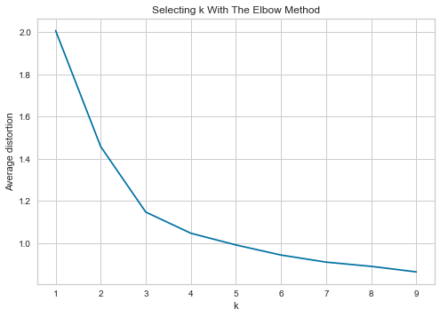

```python
## We will use the Elbow Method for determining the optimal number of clusters (k)

# Range of clusters to be fed to K-means clustering algorithm
clusters = range(1, 10)
# list to store the average distortion for each k clusters.
meanDistortions = []

for k in clusters:
    # create the K-means model with k clusters
    model = KMeans(n_clusters=k)
    # fitting the scaled data to the K-means moldel
    model.fit(scaled_df)
    # predict the closest cluster each sample in dfScaled belongs to
    prediction = model.predict(scaled_df)
    # computing the average distortion
    distortion = (
        sum(np.min(cdist(scaled_df, model.cluster_centers_, "euclidean"), axis=1))
        / scaled_df.shape[0]
    )
    # adding the distortion of the current K-means with k clusters to the list
    meanDistortions.append(distortion)

    print("Number of Clusters:", k, "\tAverage Distortion:", distortion)
# Plotting the average distorion for each k clusters K-means model
plt.plot(clusters, meanDistortions, "bx-")
plt.xlabel("k")
plt.ylabel("Average distortion")
plt.title("Selecting k With The Elbow Method")
plt.show()
```

**Observastions**

- Looking at the graph 3 looks like a good candidate for k followed by 4.

## Silhouette Score

Silhouette Score is a metric used to evaluate the quality of clustering results, such as those obtained through the k-means algorithm. It measures how well each data point fits into its assigned cluster based on the distance to points in its own cluster (cohesion) and the distance to points in the nearest neighboring cluster (separation). A higher silhouette score indicates that the clustering results are more compact and well-separated.

A silhouette score of 1 indicates that the data points are well-clustered, meaning that they are closer to the other points in their own cluster than to any points in other clusters. This is the ideal scenario.

A score of 0 means that the data points are close to the boundary between two clusters, indicating that the clustering is not clearly defined or that there may be overlapping clusters.

A score of -1 means that the data points are assigned to the wrong cluster, indicating that the clustering is completely incorrect.

```
For n_clusters = 2, silhouette score is 0.41842496663230405
For n_clusters = 3, silhouette score is 0.5157182558882754
For n_clusters = 4, silhouette score is 0.355667061937737
For n_clusters = 5, silhouette score is 0.2717470361094591
For n_clusters = 6, silhouette score is 0.2559585329109206
For n_clusters = 7, silhouette score is 0.24817058559215305
For n_clusters = 8, silhouette score is 0.225973699585381
For n_clusters = 9, silhouette score is 0.22348192672523176
```

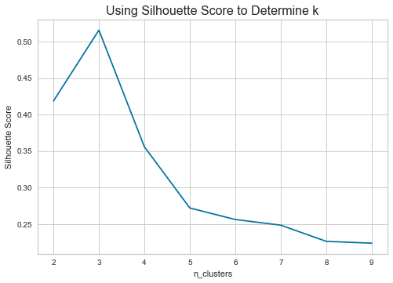

```python
sil_score = []
cluster_list = list(range(2, 10))
for n_clusters in cluster_list:
    clusterer = KMeans(n_clusters=n_clusters)
    preds = clusterer.fit_predict((scaled_df))
    # centers = clusterer.cluster_centers_
    score = silhouette_score(scaled_df, preds)
    sil_score.append(score)
    print("For n_clusters = {}, silhouette score is {}".format(n_clusters, score))

plt.ylabel("Silhouette Score")
plt.xlabel("n_clusters")
plt.title("Using Silhouette Score to Determine k", fontsize=16)

plt.plot(cluster_list, sil_score)
```

**Observations**

- According to the graph and the score, 3 looks like the optimal number for k followed by 4.
- The score for 3 clusters is 0.52 which means that the clustering algorithm has done a reasonably good job in grouping similar data points together and separating dissimilar ones into different clusters.
- The score for 4 clusters is 0.36 indicating that that there is some overlap between the clusters or that the distances between data points in different clusters are not well-separated.

### Visualizing the Silhouette Score

We will visualize this score for 3 and 4 clusters

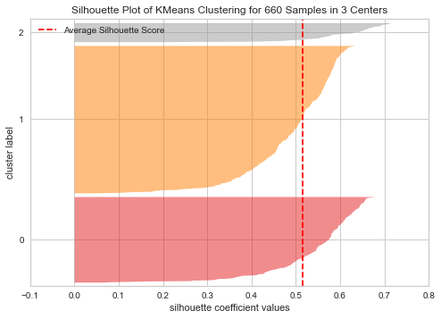

```python
# Visualizing and analyzing the optimal no. of clusters as 3  with silhouette coefficients
visualizer = SilhouetteVisualizer(KMeans(3, random_state=1))
visualizer.fit(scaled_df)
visualizer.show()
```

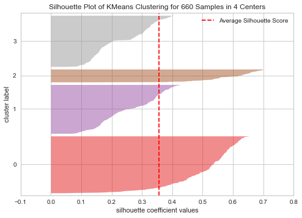

```python
# Visualizing and analyzing the optimal no. of clusters as 4  with silhouette coefficients
visualizer = SilhouetteVisualizer(KMeans(4, random_state=1))
visualizer.fit(scaled_df)
visualizer.show()
```

**Observations**

- For k=4, clusters 1 and 3 barely reach the average silhouette score of 0.36
- For k=3, all the clusters' silhouette scores reach past the average score with a more comfortable margin compared to k=4.
- k=3 is the most optimal although the population of cluster 2 seems to be relatively small.

### K Means Cluster Profiling (k=3)

```python
# Creating Kmeans model with k=3 clusters and fitting our scaled dataframe to the the model
kmeans = KMeans(n_clusters=3, random_state=1)
kmeans.fit(scaled_df)
```

```
KMeans(n_clusters=3, random_state=1)
```

```python
# adding kmeans cluster labels to the original and scaled dataframes

df["K_means_segments"] = kmeans.labels_
scaled_df["K_means_segments"] = kmeans.labels_
```

```python
cluster_profile = df.groupby("K_means_segments").mean()
```

```python
cluster_profile["CustomerCount"] = (
    df.groupby("K_means_segments")["Total_Credit_Cards"].count().values
)
```

```python
cluster_profile.style.highlight_max(axis=0)
```

| K_means_segments | Avg_Credit_Limit | Total_Credit_Cards | Total_visits_bank | Total_visits_online | Total_calls_made | CustomerCount |
| --- | --- | --- | --- | --- | --- | --- |
| 0 | 12174.107143 | 2.410714 | 0.933036 | 3.553571 | 6.870536 | 224 |
| 1 | 33782.383420 | 5.515544 | 3.489637 | 0.981865 | 2.000000 | 386 |
| 2 | 141040.000000 | 8.740000 | 0.600000 | 10.900000 | 1.080000 | 50 |

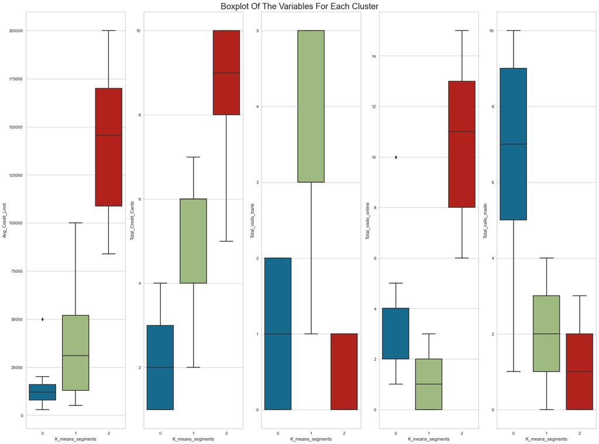

```python
fig, axes = plt.subplots(1, df.shape[1] - 1, figsize=(20, 15))
fig.suptitle("Boxplot Of The Variables For Each Cluster", fontsize=20)
counter = 0
for ii in range(df.shape[1]):
    if (
        df.columns[ii] != "K_means_segments"
    ):  # This avoids plotting K_means_segments against itself
        sns.boxplot(
            ax=axes[counter], y=df.iloc[:, ii], x=df["K_means_segments"],
        )
        counter += 1

fig.tight_layout(pad=1)
```

**Observations**

# Hierarchical Clustering

Above we applied K Means Clustering, and here we will apply Hierarchical Clustering. These are some of the differences between the two:

Methodology: K-means clustering is a centroid-based clustering method, where each cluster is represented by a centroid (the center point of all the points in the cluster), while hierarchical clustering is a linkage-based clustering method, which creates a hierarchical tree-like structure of clusters based on the similarity between data points.

Number of clusters: In K-means clustering, the number of clusters needs to be specified in advance, while in hierarchical clustering, the number of clusters is determined by the structure of the hierarchical tree.

Flexibility: Hierarchical clustering is more flexible than K-means clustering in terms of the types of distances or dissimilarities used to group data points.

Interpretability: Hierarchical clustering provides a visual representation of the clustering structure in the form of a dendrogram, which allows for easy interpretation of the relationship between clusters. K-means clustering does not provide such a visualization.

Scalability: K-means clustering is faster and more scalable than hierarchical clustering for large datasets.

Overall, the choice between K-means clustering and hierarchical clustering depends on the specific problem at hand, the size of the dataset, and the desired level of interpretability.

```python
df.info()
```

```
<class 'pandas.core.frame.DataFrame'>
RangeIndex: 660 entries, 0 to 659
Data columns (total 6 columns):
 #   Column               Non-Null Count  Dtype
---  ------               --------------  -----
 0   Avg_Credit_Limit     660 non-null    int64
 1   Total_Credit_Cards   660 non-null    int64
 2   Total_visits_bank    660 non-null    int64
 3   Total_visits_online  660 non-null    int64
 4   Total_calls_made     660 non-null    int64
 5   K_means_segments     660 non-null    int32
dtypes: int32(1), int64(5)
memory usage: 28.5 KB
```

```python
scaled_df.info()
```

```
<class 'pandas.core.frame.DataFrame'>
RangeIndex: 660 entries, 0 to 659
Data columns (total 6 columns):
 #   Column               Non-Null Count  Dtype
---  ------               --------------  -----
 0   Avg_Credit_Limit     660 non-null    float64
 1   Total_Credit_Cards   660 non-null    float64
 2   Total_visits_bank    660 non-null    float64
 3   Total_visits_online  660 non-null    float64
 4   Total_calls_made     660 non-null    float64
 5   K_means_segments     660 non-null    int32
dtypes: float64(5), int32(1)
memory usage: 28.5 KB
```

**Observations**

- We need to drop the K_means_segments column from our scaled and original data frames. If we were using much larger data I would keep clean copies of each to not drop that column.

```python
# Dropping K_means_segments
df.drop(["K_means_segments"], axis=1, inplace=True)
scaled_df.drop(["K_means_segments"], axis=1, inplace=True)
```

## Cophenetic Corelation Analysis

The cophenetic correlation coefficient is a measure of the correlation between the cophenetic distances and the original distances of the objects. The cophenetic distance between two objects is the height of the node where they first join together in the dendrogram.

The coefficient ranges from 0 to 1, where a value of 1 indicates a perfect match between the dendrogram and the original distances. Higher values of the coefficient indicate better agreement between the dendrogram and the original distances, while lower values indicate poorer agreement. In general, a coefficient above 0.7 is considered to be a good match, while values below 0.5 indicate a poor match.

A higher coefficient indicates that the dendrogram accurately represents the original distances between the objects and is a good representation of the data. Conversely, a lower coefficient suggests that the dendrogram may not be a good representation of the underlying structure of the data.

```python
# list of distance metrics
distance_metrics = [
    "canberra",
    "chebyshev",
    "cityblock",
    "correlation",
    "cosine",
    "euclidean",
    "hamming",
    "jaccard",
    "mahalanobis",
    "matching",
    "minkowski",
]

# list of linkage methods
linkage_methods = ["complete", "average", "single", "weighted"]

high_cophenet_corr = 0
high_dm_lm = [0, 0]

for dm in distance_metrics:
    for lm in linkage_methods:
        Z = linkage(scaled_df, metric=dm, method=lm)
        c, coph_dists = cophenet(Z, pdist(scaled_df))
        print(
            "Cophenetic correlation for {} distance and {} linkage is {}.".format(
                dm.capitalize(), lm, c
            )
        )
        if high_cophenet_corr < c:
            high_cophenet_corr = c
            high_dm_lm[0] = dm
            high_dm_lm[1] = lm
```

```
Cophenetic correlation for Canberra distance and complete linkage is 0.46069443891594597.
Cophenetic correlation for Canberra distance and average linkage is 0.6751521558776901.
Cophenetic correlation for Canberra distance and single linkage is 0.7566178713003985.
Cophenetic correlation for Canberra distance and weighted linkage is 0.5351232761249246.
Cophenetic correlation for Chebyshev distance and complete linkage is 0.8533474836336782.
Cophenetic correlation for Chebyshev distance and average linkage is 0.8974159511838106.
Cophenetic correlation for Chebyshev distance and single linkage is 0.7382354769296767.
Cophenetic correlation for Chebyshev distance and weighted linkage is 0.8913624010768603.
Cophenetic correlation for Cityblock distance and complete linkage is 0.8731477899179829.
Cophenetic correlation for Cityblock distance and average linkage is 0.896329431104133.
Cophenetic correlation for Cityblock distance and single linkage is 0.7252379350252723.
Cophenetic correlation for Cityblock distance and weighted linkage is 0.8825520731498188.
Cophenetic correlation for Correlation distance and complete linkage is 0.48880336464362406.
Cophenetic correlation for Correlation distance and average linkage is 0.6601199957880307.
Cophenetic correlation for Correlation distance and single linkage is 0.6102702201143325.
Cophenetic correlation for Correlation distance and weighted linkage is 0.5317441799993322.
Cophenetic correlation for Cosine distance and complete linkage is 0.5316900096793689.
Cophenetic correlation for Cosine distance and average linkage is 0.6720803242310263.
Cophenetic correlation for Cosine distance and single linkage is 0.7473448481710088.
Cophenetic correlation for Cosine distance and weighted linkage is 0.5660201015465876.
Cophenetic correlation for Euclidean distance and complete linkage is 0.8599730607972423.
Cophenetic correlation for Euclidean distance and average linkage is 0.8977080867389372.
Cophenetic correlation for Euclidean distance and single linkage is 0.7391220243806552.
Cophenetic correlation for Euclidean distance and weighted linkage is 0.8861746814895477.
Cophenetic correlation for Hamming distance and complete linkage is 0.20179683067025023.
Cophenetic correlation for Hamming distance and average linkage is 0.5473662896769675.
Cophenetic correlation for Hamming distance and single linkage is 0.7080851663862526.
Cophenetic correlation for Hamming distance and weighted linkage is 0.6057204454928228.
Cophenetic correlation for Jaccard distance and complete linkage is 0.20179683067025023.
Cophenetic correlation for Jaccard distance and average linkage is 0.5473662896769675.
Cophenetic correlation for Jaccard distance and single linkage is 0.7080851663862526.
Cophenetic correlation for Jaccard distance and weighted linkage is 0.6057204454928228.
Cophenetic correlation for Mahalanobis distance and complete linkage is 0.666353446387536.
Cophenetic correlation for Mahalanobis distance and average linkage is 0.8326994115042136.
Cophenetic correlation for Mahalanobis distance and single linkage is 0.7058064784553605.
Cophenetic correlation for Mahalanobis distance and weighted linkage is 0.7805990615142517.
Cophenetic correlation for Matching distance and complete linkage is 0.20179683067025023.
Cophenetic correlation for Matching distance and average linkage is 0.5473662896769675.
Cophenetic correlation for Matching distance and single linkage is 0.7080851663862526.
Cophenetic correlation for Matching distance and weighted linkage is 0.6057204454928228.
Cophenetic correlation for Minkowski distance and complete linkage is 0.8599730607972423.
Cophenetic correlation for Minkowski distance and average linkage is 0.8977080867389372.
Cophenetic correlation for Minkowski distance and single linkage is 0.7391220243806552.
Cophenetic correlation for Minkowski distance and weighted linkage is 0.8861746814895477.
```

```python
# printing the combination of distance metric and linkage method with the highest cophenetic correlation
print(
    "Highest cophenetic correlation is {}, which is obtained with {} distance and {} linkage.".format(
        high_cophenet_corr, high_dm_lm[0].capitalize(), high_dm_lm[1]
    )
)
```

```
Highest cophenetic correlation is 0.8977080867389372, which is obtained with Euclidean distance and average linkage.
```

### Now we will look at only Euclidean distance

```python
distance_metrics = ["euclidean"]

# list of linkage methods
linkage_methods = ["single", "complete", "average", "centroid", "ward", "weighted"]

high_cophenet_corr = 0
high_dm_lm = [0, 0]

for dm in distance_metrics:
    for lm in linkage_methods:
        Z = linkage(scaled_df, metric=dm, method=lm)
        c, coph_dists = cophenet(Z, pdist(scaled_df))
        print(
            "Cophenetic correlation for {} distance and {} linkage is {}.".format(
                dm.capitalize(), lm, c
            )
        )
        if high_cophenet_corr < c:
            high_cophenet_corr = c
            high_dm_lm[0] = dm
            high_dm_lm[1] = lm
```

```
Cophenetic correlation for Euclidean distance and single linkage is 0.7391220243806552.
Cophenetic correlation for Euclidean distance and complete linkage is 0.8599730607972423.
Cophenetic correlation for Euclidean distance and average linkage is 0.8977080867389372.
Cophenetic correlation for Euclidean distance and centroid linkage is 0.8939385846326323.
Cophenetic correlation for Euclidean distance and ward linkage is 0.7415156284827493.
Cophenetic correlation for Euclidean distance and weighted linkage is 0.8861746814895477.
```

```python
# printing the combination of distance metric and linkage method with the highest cophenetic correlation
print(
    "Highest cophenetic correlation is {}, which is obtained with {} distance and {} linkage.".format(
        high_cophenet_corr, high_dm_lm[0].capitalize(), high_dm_lm[1]
    )
)
```

```
Highest cophenetic correlation is 0.8977080867389372, which is obtained with Euclidean distance and average linkage.
```

**Observations**

- The hightest corelation is for Euclidean distance with average linkage, the second highest correlation for Euclidean is with centroid linkage.

## Dendogram Visualization

Now we will look at Dendograms for the different linkage methods

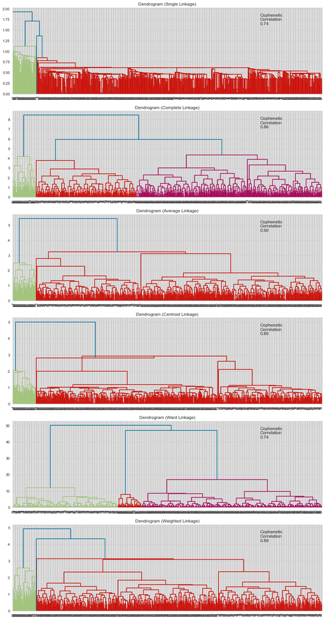

```python
# list of linkage methods
linkage_methods = ["single", "complete", "average", "centroid", "ward", "weighted"]

# lists to save results of cophenetic correlation calculation
compare_cols = ["Linkage", "Cophenetic Coefficient"]
compare = []

# to create a subplot image
fig, axs = plt.subplots(len(linkage_methods), 1, figsize=(15, 30))

# We will enumerate through the list of linkage methods above
# For each linkage method, we will plot the dendrogram and calculate the cophenetic correlation
for i, method in enumerate(linkage_methods):
    Z = linkage(scaled_df, metric="euclidean", method=method)

    dendrogram(Z, ax=axs[i])
    axs[i].set_title(f"Dendrogram ({method.capitalize()} Linkage)")

    coph_corr, coph_dist = cophenet(Z, pdist(scaled_df))
    axs[i].annotate(
        f"Cophenetic\nCorrelation\n{coph_corr:0.2f}",
        (0.80, 0.80),
        xycoords="axes fraction",
    )

    compare.append([method, coph_corr])
```

```python
# Display in table format the Cophenetic Coefficients
df_cc = pd.DataFrame(compare, columns=compare_cols)
df_cc
```

|  | Linkage | Cophenetic Coefficient |
| --- | --- | --- |
| 0 | single | 0.74 |
| 1 | complete | 0.86 |
| 2 | average | 0.90 |
| 3 | centroid | 0.89 |
| 4 | ward | 0.74 |
| 5 | weighted | 0.89 |

**Observations**

- The Ward linkage has the cleanest clusters but it's tied for the lowest Cophenetic Correlation with Single linkage at 0.74.
- The highest cophenetic correlation is Average linkage at 0.90.
- From the dendogram the optimal number of clusters seems to be 4.

```python
HCmodel = AgglomerativeClustering(n_clusters=4, affinity="euclidean", linkage="average")
HCmodel.fit(scaled_df)
```

```
AgglomerativeClustering(linkage='average', n_clusters=4)
```

```python
scaled_df["HC_Cluster"] = HCmodel.labels_
df["HC_Cluster"] = HCmodel.labels_
```

```python
# viewing a random sample of the dataset
df.sample(n=10, random_state=1)
```

|  | Avg_Credit_Limit | Total_Credit_Cards | Total_visits_bank | Total_visits_online | Total_calls_made | HC_Cluster |
| --- | --- | --- | --- | --- | --- | --- |
| 547 | 26000 | 4 | 5 | 2 | 4 | 2 |
| 353 | 9000 | 5 | 4 | 1 | 3 | 2 |
| 499 | 68000 | 6 | 4 | 2 | 2 | 2 |
| 173 | 9000 | 2 | 1 | 5 | 8 | 0 |
| 241 | 10000 | 4 | 5 | 1 | 3 | 2 |
| 341 | 18000 | 4 | 3 | 2 | 0 | 2 |
| 647 | 183000 | 9 | 0 | 9 | 2 | 1 |
| 218 | 19000 | 3 | 1 | 5 | 7 | 0 |
| 120 | 10000 | 4 | 2 | 4 | 6 | 0 |
| 134 | 13000 | 4 | 1 | 5 | 7 | 0 |

## Hierarchical Cluster Profiling

```python
h_cluster_profile = df.groupby("HC_Cluster").mean()
```

```python
# Let's see how many customers are in each cluster
df.HC_Cluster.value_counts()
```

```
2    386
0    223
1     50
3      1
Name: HC_Cluster, dtype: int64
```

**Observations**

- Cluster 3 (the 4th cluster) only has one customer in it

```python
h_cluster_profile["CustomerCount"] = (
    df.groupby("HC_Cluster")["Avg_Credit_Limit"].count().values
)

h_cluster_profile.style.highlight_max(axis=0)
```

| HC_Cluster | Avg_Credit_Limit | Total_Credit_Cards | Total_visits_bank | Total_visits_online | Total_calls_made | CustomerCount |
| --- | --- | --- | --- | --- | --- | --- |
| 0 | 12197.309417 | 2.403587 | 0.928251 | 3.560538 | 6.883408 | 223 |
| 1 | 141040.000000 | 8.740000 | 0.600000 | 10.900000 | 1.080000 | 50 |
| 2 | 33541.450777 | 5.520725 | 3.492228 | 0.984456 | 2.010363 | 386 |
| 3 | 100000.000000 | 2.000000 | 1.000000 | 1.000000 | 0.000000 | 1 |

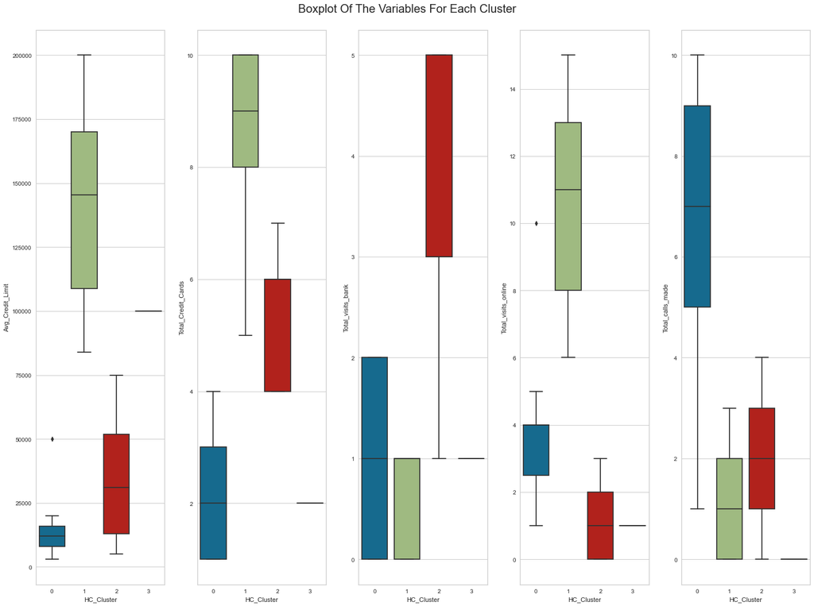

```python
fig, axes = plt.subplots(1, df.shape[1] - 1, figsize=(20, 15))
fig.suptitle("Boxplot Of The Variables For Each Cluster", fontsize=20)
counter = 0
for ii in range(df.shape[1]):
    if df.columns[ii] != "HC_Cluster":  # This avoids plotting HC_Cluster against itself
        sns.boxplot(
            ax=axes[counter], y=df.iloc[:, ii], x=df["HC_Cluster"],
        )
        counter += 1

fig.tight_layout(pad=2)
```

**Observations**

- Cluster 0:
  - Has the hightest Total_calls_made
  - This cluster has the second largest number of customers in it
- Cluster 1:
  - Has the highest Avg_Credit_Limit, Toral_Credit_Cards and Total_vists_online
- Cluster 2:
  - Has the highest Total_visits_bank and the largest number of customers
- Cluster 3:
  - This cluster only has one customer in it who has a high Avg_Credit_Limit (but not the highest).
- We also ran this with 3 clusters instead of 4 to see if we could get rid of the cluster with just one customer but this was not succesful and still ended up with a cluster of one customer.

# SUMMARY

## Comparison of K Means Clustering to Hierarchical Clustering

- As stated before an issue with the Hierarchical Clustering with 4 clusters is that we ended up with a cluster that only has one customer in it. To overcome this issue we reran it with three clusters but still ended up with that same lone cluster.
- We recommend to rerun the hierarchical analysis with Manhattan distance which is less sensitive to outliers which we have in some features. We could also keep the analysis with Euclidian but with different linkage types different from Average linkage to see if we can improve the clustering.
- The Hierarchical analysis took longer than K Means beacuse of the dendograms, this would be more of a problem with larger data sets but in this instance with only 660 records and several columns it was not a big impact.

## Business Comments and Recommendations (based on K Means Analysis)

- We recommend classifying the customer base into 3 clusters.
- Cluster 0: -This is the cluster with the highest number of Total_calls_made and the largest range of the same (from 1 to 10). Targetting these customers with a marketing campaign to encourage online banking would be beneficial and reduce calls to the call center which is expensive compared to online.
  - This cluster also has the lowest Total_Credits_Cards and Avg_Credit_Limit but it is not shown that increasing their credit limits of number of credit cards would decrease call center calls.
- Cluster 1:
  - Customers in this cluster had the highest Total_visits_bank and the largest number of customers. It also had the lowest Total_visits_online. As in Cluster 0, it would be benefcial to target these customers with a marketing campaign to encourage online banking would be beneficial and visits to the bank thereby reducing costs. Since this is the largest cluster, we could have a big impact targetting this segment.
- Cluster 2:
  - This cluster has the highest Total_visits_online and it is the smallest cluster as well so it does not make sense to make this cluster a priority for any marketing campaigns for existing customers. However, this cluster is an excellent opprtunity for people who are not yet customers because they are low cost and since they have the highest number of credit cards they are high yield customers.